# variational Inference SAEM

In this document, we will introduce a new proposal for our Metropolis hastings algorithm. The construction of this kernel is based off of approximation methods that consist in approximating the incomplete log likelihood. The following methods are applicable to continuous and discrete hierarchical models (the likelihood is whether discrete or continuous and the prior on the latent variable is always continuous).

# Incremental SAEM

### Yield case

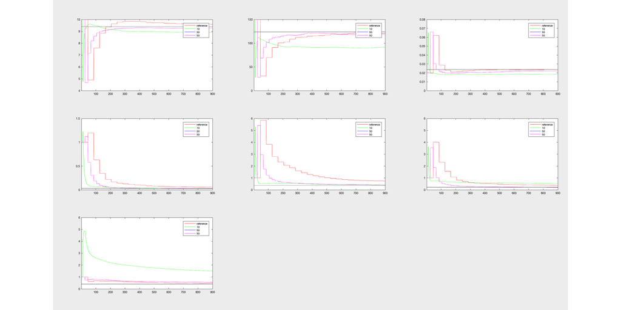

### Cow case

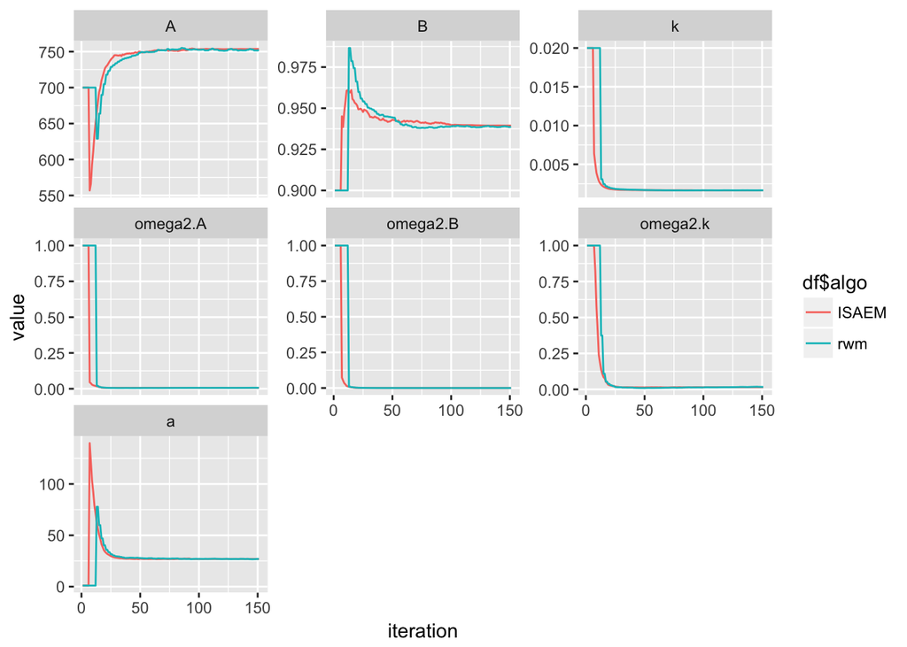

# FOCE SAEM

### Yield case

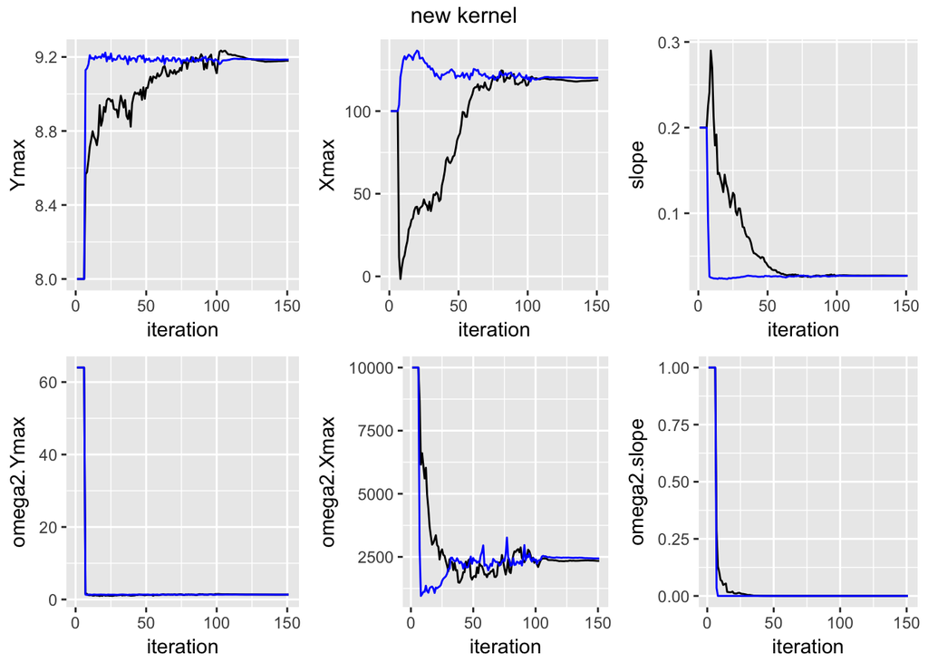

#### SAEM ref vs SAEM_MIX_FOCE_RWM

Another solution consists in mixing the costly algorithm with RWM. Basically, we compute the MAP for the first X iterations, propose via the same independent proposal and then switch to the RWM. According to the models (linear gaussian, Theo, Cow, YieldLP) the number of times the MAP has to be computed at the beginning varies but for all cases it is always better to propose via the FOCE proposal during the first iterations of SAEM and then switch to the regular RWM rather than using this new kernel from time to time.

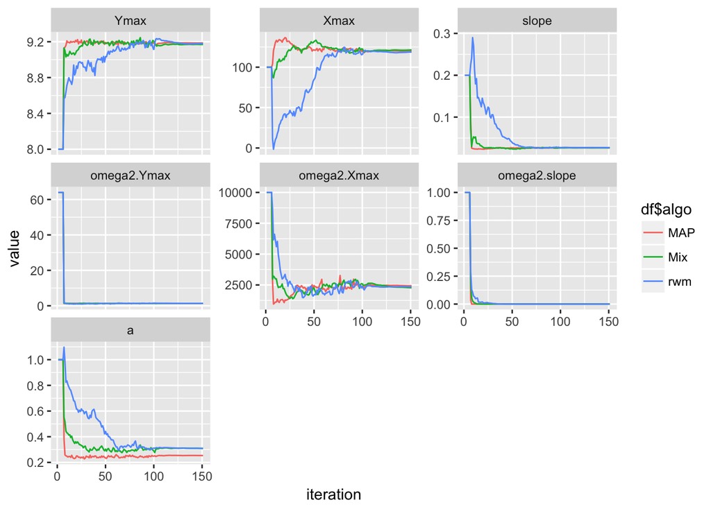

# MAMYULA SAEM

### Theo case

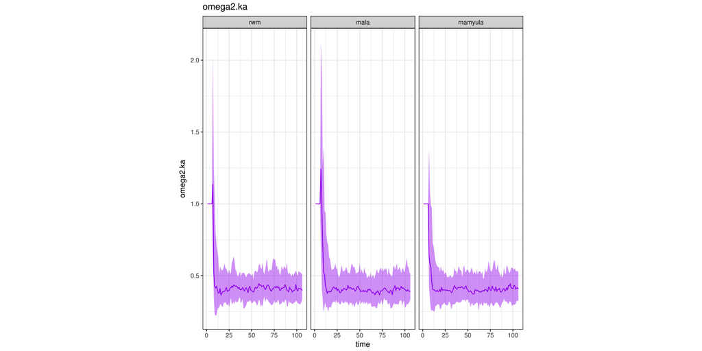